# Through the eyes of the teacher - Multimodal exploration of expertise differences in the perception of classroom disruptions in a laboratory study

### 2.3 Situational Jugdement Test

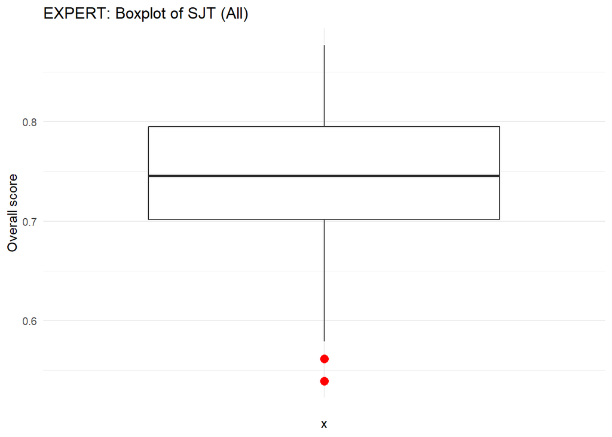

[1] 41 [1] 39

| Participant | Monitoring | Managing momentum | Rules and routines | All | Group |
| --- | --- | --- | --- | --- | --- |
| 216 | 0.5126263 | 0.6095238 | 0.4958333 | 0.5393278 | Expert |
| 217 | 0.4656566 | 0.5984127 | 0.6202381 | 0.5614358 | Expert |

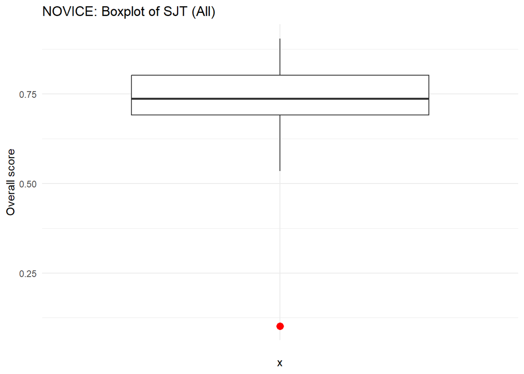

[1] 42 [1] 41

| Participant | Monitoring | Managing momentum | Rules and routines | All | Group |
| --- | --- | --- | --- | --- | --- |
| 127 | 0.15 | 0.08095238 | 0.075 | 0.1019841 | Novice |

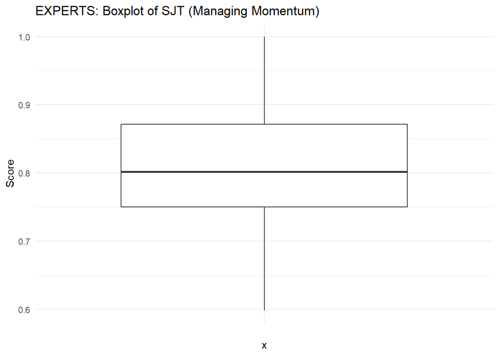

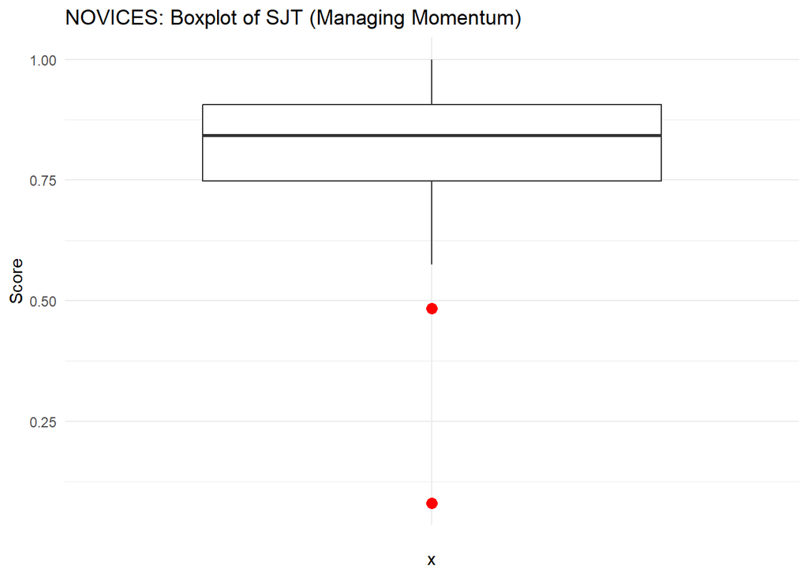

[1] 42 [1] 40

| Participant | Monitoring | Managing momentum | Rules and routines | All | Group |
| --- | --- | --- | --- | --- | --- |
| 105 | 0.6207071 | 0.48359788 | 0.8270833 | 0.6437961 | Novice |
| 127 | 0.1500000 | 0.08095238 | 0.0750000 | 0.1019841 | Novice |

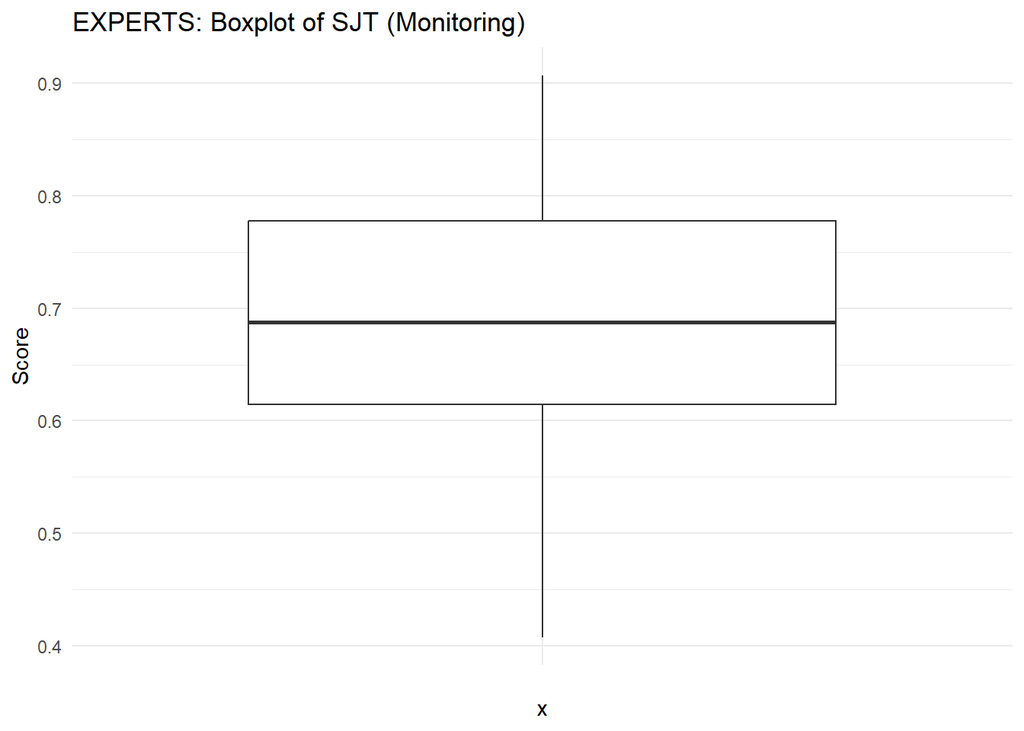

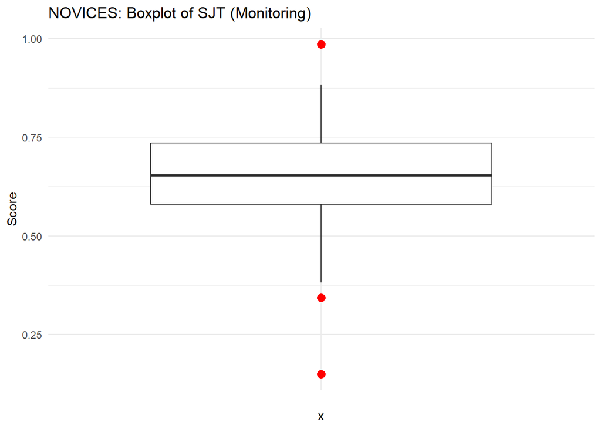

[1] 42 [1] 39

| Participant | Monitoring | Managing momentum | Rules and routines | All | Group |
| --- | --- | --- | --- | --- | --- |
| 121 | 0.9861111 | 0.86719577 | 0.5627976 | 0.8053682 | Novice |
| 127 | 0.1500000 | 0.08095238 | 0.0750000 | 0.1019841 | Novice |
| 137 | 0.3431818 | 0.77195767 | 0.6354167 | 0.5835187 | Novice |

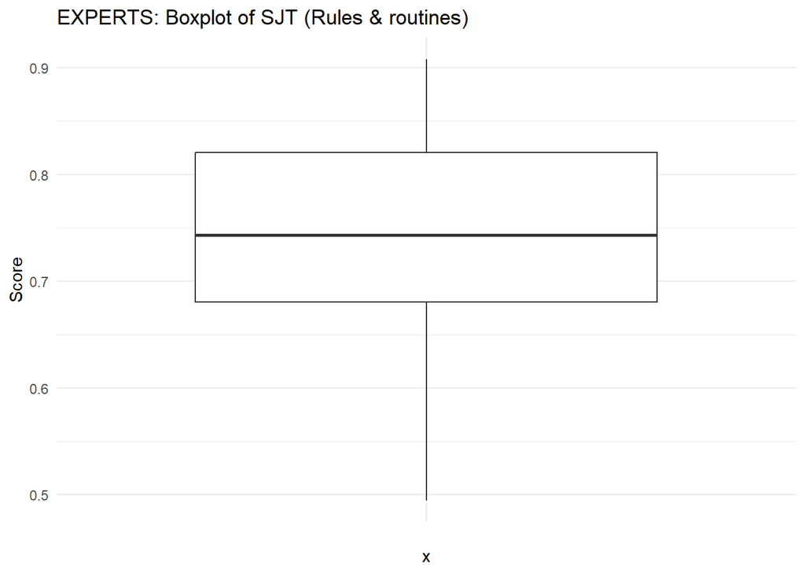

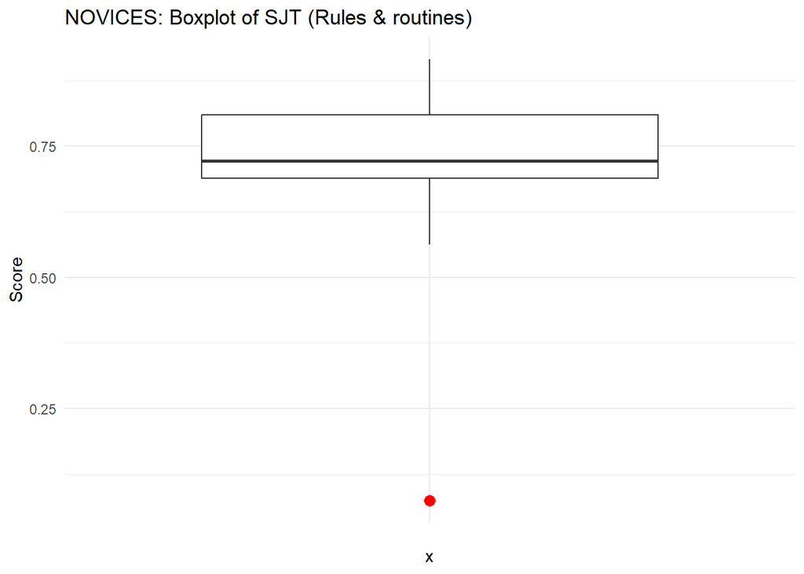

[1] 42 [1] 41

| Participant | Monitoring | Managing momentum | Rules and routines | All | Group |
| --- | --- | --- | --- | --- | --- |
| 127 | 0.15 | 0.08095238 | 0.075 | 0.1019841 | Novice |

N, M and SD for overall value

| Group | N | M | SD | Min | Max |
| --- | --- | --- | --- | --- | --- |
| Expert | 39 | 0.76 | 0.07 | 0.58 | 0.88 |
| Novice | 41 | 0.74 | 0.08 | 0.53 | 0.91 |

N, M and SD for managing momentum

| Group | N | M | SD | Min | Max |
| --- | --- | --- | --- | --- | --- |
| Expert | 41 | 0.81 | 0.10 | 0.60 | 1 |
| Novice | 40 | 0.83 | 0.11 | 0.57 | 1 |

N, M and SD for monitoring

| Group | N | M | SD | Min | Max |
| --- | --- | --- | --- | --- | --- |
| Expert | 41 | 0.69 | 0.13 | 0.41 | 0.91 |
| Novice | 39 | 0.65 | 0.12 | 0.38 | 0.88 |

N, M and SD for rules and routines

| Group | N | M | SD | Min | Max |
| --- | --- | --- | --- | --- | --- |
| Expert | 41 | 0.74 | 0.10 | 0.49 | 0.91 |
| Novice | 41 | 0.74 | 0.09 | 0.56 | 0.92 |

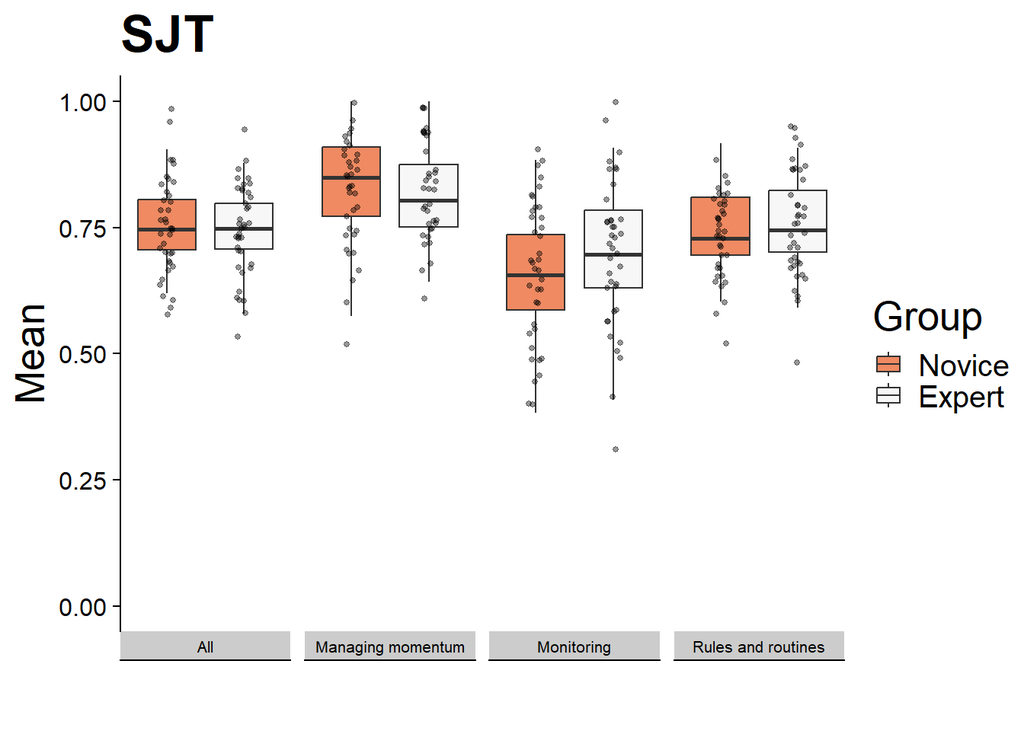

#### t-test & effect size “STJ - All”

```
Two Sample t-test
```

data: df_sjt_mean_all_no_out$All[df_sjt_mean_all_no_out$Group == “Expert”] and df_sjt_mean_all_no_out$All[df_sjt_mean_all_no_out$Group == “Novice”] t = 1.007, df = 78, p-value = 0.317 alternative hypothesis: true difference in means is not equal to 0 95 percent confidence interval: -0.01637089 0.04988593 sample estimates: mean of x mean of y 0.7556688 0.7389113

[1] 0.23 attr(,“magnitude”) [1] “small”

#### t-test & effect size “SJT - Managing momentum”

```
Two Sample t-test
```

data: df_sjt_mean_mm_no_out$`Managing momentum`[df_sjt_mean_mm_no_out$Group == “Expert”] and df_sjt_mean_mm_no_out$`Managing momentum`[df_sjt_mean_mm_no_out$Group == “Novice”] t = -0.9457, df = 79, p-value = 0.3472 alternative hypothesis: true difference in means is not equal to 0 95 percent confidence interval: -0.06706136 0.02386192 sample estimates: mean of x mean of y 0.8092270 0.8308267

[1] -0.21 attr(,“magnitude”) [1] “small”

#### t-test & effect size “SJT - Monitoring”

```
Two Sample t-test
```

data: df_sjt_mean_m_no_out$Monitoring[df_sjt_mean_m_no_out$Group == “Expert”] and df_sjt_mean_m_no_out$Monitoring[df_sjt_mean_m_no_out$Group == “Novice”] t = 1.2169, df = 78, p-value = 0.2273 alternative hypothesis: true difference in means is not equal to 0 95 percent confidence interval: -0.02167305 0.08983245 sample estimates: mean of x mean of y 0.6877186 0.6536390

[1] 0.27 attr(,“magnitude”) [1] “small”

#### t-test & effect size “SJT - Rules & routines”

```
Two Sample t-test
```

data: df_sjt_mean_r_no_out$`Rules and routines`[df_sjt_mean_r_no_out$Group == “Expert”] and df_sjt_mean_r_no_out$`Rules and routines`[df_sjt_mean_r_no_out$Group == “Novice”] t = -0.0086906, df = 80, p-value = 0.9931 alternative hypothesis: true difference in means is not equal to 0 95 percent confidence interval: -0.04173773 0.04137478 sample estimates: mean of x mean of y 0.7400189 0.7402003

[1] 0 attr(,“magnitude”) [1] “negligible”

### Internal consistency (Omega) for SJT

[figure not shown]

Omega Call: omegah(m = m, nfactors = nfactors, fm = fm, key = key, flip = flip, digits = digits, title = title, sl = sl, labels = labels, plot = plot, n.obs = n.obs, rotate = rotate, Phi = Phi, option = option, covar = covar) Alpha: 0.68 G.6: 0.9 Omega Hierarchical: 0.66 Omega H asymptotic: 0.88 Omega Total 0.75

Schmid Leiman Factor loadings greater than 0.2 g F1* F2* F3* h2 h2 u2 p2 com WT_S1_F1F2_AL 0.35 0.15 0.85 0.13 1.47 WT_S1_F1F3_AL 0.25 0.33 0.19 0.81 0.32 2.20 WT_S1_F1F5_AL 0.26 -0.55 0.38 0.38 0.62 0.04 1.54 WT_S1_F2F4_AL 0.49 0.31 0.35 0.35 0.65 0.69 1.81 WT_S1_F2F5_AL 0.63 0.42 0.42 0.58 0.00 1.13 WT_S1_F2F6_AL 0.57 0.35 0.35 0.65 0.01 1.16 WT_S1_F3F4_AL 0.57 0.36 0.36 0.64 0.90 1.21 WT_S1_F3F5_AL 0.78 0.61 0.61 0.39 0.00 1.02 WT_S1_F3F6_AL 0.44 0.23 0.23 0.77 0.05 1.33 WT_S1_F4F5_AL 0.60 -0.39 0.52 0.52 0.48 0.69 1.75 WT_S1_F4F6_AL 0.47 -0.20 0.27 0.27 0.73 0.84 1.38 WT_S1_F5F6_AL 0.42 -0.50 0.45 0.45 0.55 0.07 2.20 WT_S2_F1F3_AL 0.33 0.14 0.86 0.02 1.52 WT_S2_F1F4_AL- -0.24 0.10 0.90 0.07 2.13 WT_S2_F1F6_AL 0.49 -0.24 0.32 0.32 0.68 0.11 1.78 WT_S2_F2F3_AL 0.22 0.44 0.24 0.24 0.76 0.20 1.48 WT_S2_F2F5_AL 0.32 -0.35 0.23 0.23 0.77 0.45 2.06 WT_S2_F2F6_AL 0.26 0.54 0.37 0.37 0.63 0.19 1.48 WT_S2_F3F4_AL- 0.31 -0.52 0.38 0.38 0.62 0.26 1.66 WT_S2_F3F5_AL- -0.33 -0.35 0.26 0.26 0.74 0.09 2.37 WT_S2_F4F5_AL- -0.31 0.15 0.85 0.14 2.13 WT_S2_F4F6_AL- -0.69 0.48 0.48 0.52 0.01 1.01 WT_S2_F5F6_AL 0.51 0.38 0.42 0.42 0.58 0.01 1.89 WT_S3_F1F2_AL- 0.25 -0.24 0.13 0.87 0.50 2.14 WT_S3_F1F3_AL 0.32 0.12 0.88 0.11 1.31 WT_S3_F1F4_AL- -0.20 0.05 0.95 0.04 1.27 WT_S3_F1F5_AL- 0.26 -0.24 0.13 0.87 0.54 2.02 WT_S3_F2F7_AL 0.31 0.21 0.16 0.84 0.57 2.37 WT_S3_F3F7_AL 0.38 0.15 0.85 0.94 1.13 WT_S3_F4F7_AL 0.24 0.06 0.94 0.86 1.33 WT_S3_F5F7_AL 0.34 0.13 0.87 0.89 1.24 WT_S4_F1F2_AL 0.29 0.21 0.16 0.84 0.53 2.49 WT_S4_F1F3_AL 0.30 0.36 0.23 0.23 0.77 0.38 2.21 WT_S4_F1F4_AL 0.20 0.06 0.94 0.64 1.86 WT_S4_F1F5_AL- 0.27 -0.29 0.16 0.84 0.46 2.10 WT_S4_F1F6_AL- -0.63 0.43 0.43 0.57 0.08 1.18 WT_S4_F2F3_AL -0.22 0.06 0.94 0.07 1.50 WT_S4_F2F6_AL- 0.47 -0.35 0.24 0.40 0.40 0.60 0.56 2.40 WT_S4_F3F4_AL 0.23 0.06 0.94 0.00 1.08 WT_S4_F4F6_AL- 0.26 -0.26 0.14 0.86 0.49 2.10

With Sums of squares of: g F1* F2* F3* h2 2.88 4.10 3.00 0.01 3.35

general/max 0.7 max/min = 293.69 mean percent general = 0.32 with sd = 0.31 and cv of 0.95 Explained Common Variance of the general factor = 0.29

The degrees of freedom are 663 and the fit is 18.76 The number of observations was 84 with Chi Square = 1253.73 with prob < 6.8e-39 The root mean square of the residuals is 0.11 The df corrected root mean square of the residuals is 0.12 RMSEA index = 0.102 and the 10 % confidence intervals are 0.095 0.112 BIC = -1683.9

Compare this with the adequacy of just a general factor and no group factors The degrees of freedom for just the general factor are 740 and the fit is 24.06 The number of observations was 84 with Chi Square = 1639.81 with prob < 5e-70 The root mean square of the residuals is 0.17 The df corrected root mean square of the residuals is 0.17

RMSEA index = 0.12 and the 10 % confidence intervals are 0.113 0.129 BIC = -1639

Measures of factor score adequacy  
g F1* F2* F3* Correlation of scores with factors 0.90 0.93 0.92 0.06 Multiple R square of scores with factors 0.81 0.87 0.84 0.00 Minimum correlation of factor score estimates 0.62 0.73 0.69 -0.99

Total, General and Subset omega for each subset g F1* F2* F3* Omega total for total scores and subscales 0.75 0.56 0.39 NA Omega general for total scores and subscales 0.66 0.53 0.38 NA Omega group for total scores and subscales 0.01 0.03 0.00 NA

[figure not shown]

Omega Call: omegah(m = m, nfactors = nfactors, fm = fm, key = key, flip = flip, digits = digits, title = title, sl = sl, labels = labels, plot = plot, n.obs = n.obs, rotate = rotate, Phi = Phi, option = option, covar = covar) Alpha: 0.81 G.6: 0.95 Omega Hierarchical: 0.13 Omega H asymptotic: 0.16 Omega Total 0.84

Schmid Leiman Factor loadings greater than 0.2 g F1* F2* F3* h2 h2 u2 p2 com WT_S5_F1F2_ST 0.28 0.11 0.89 0.09 1.90 WT_S5_F1F3_ST 0.41 0.20 0.20 0.80 0.07 1.46 WT_S5_F1F4_ST 0.37 0.19 0.81 0.06 1.74 WT_S5_F1F5_ST 0.27 -0.22 0.53 0.42 0.42 0.58 0.05 2.08 WT_S5_F2F6_ST- 0.04 0.96 0.00 1.68 WT_S5_F3F5_ST- 0.20 0.08 0.92 0.02 2.57 WT_S5_F3F6_ST 0.20 0.05 0.95 0.10 1.30 WT_S5_F4F6_ST 0.05 0.95 0.14 2.61 WT_S6_F1F2_ST 0.26 0.55 0.34 0.49 0.49 0.51 0.13 2.15 WT_S6_F1F3_ST 0.25 0.64 0.50 0.50 0.50 0.13 1.44 WT_S6_F1F5_ST 0.23 0.51 0.34 0.34 0.66 0.15 1.61 WT_S6_F1F6_ST 0.25 0.64 0.48 0.48 0.52 0.13 1.35 WT_S6_F2F3_ST 0.07 0.93 0.02 2.50 WT_S6_F2F4_ST 0.55 0.35 0.35 0.65 0.09 1.34 WT_S6_F2F5_ST 0.24 -0.21 0.13 0.87 0.05 2.87 WT_S6_F3F4_ST 0.22 0.62 0.45 0.45 0.55 0.11 1.39 WT_S6_F4F5_ST 0.25 0.71 0.58 0.58 0.42 0.10 1.32 WT_S6_F4F6_ST 0.43 0.21 0.21 0.79 0.11 1.33 WT_S7_F1F6_ST 0.64 0.48 0.48 0.52 0.07 1.37 WT_S7_F1F7_ST 0.47 0.30 0.35 0.35 0.65 0.08 2.09 WT_S7_F2F6_ST 0.24 0.29 0.17 0.83 0.09 2.78 WT_S7_F3F6_ST 0.32 0.30 -0.30 0.30 0.30 0.70 0.06 3.30 WT_S7_F3F7_ST 0.23 0.37 0.24 0.24 0.76 0.07 2.42 WT_S7_F4F6_ST 0.30 0.37 0.28 0.28 0.72 0.08 2.78 WT_S7_F5F6_ST 0.21 0.55 0.37 0.37 0.63 0.12 1.49 WT_S7_F5F7_ST 0.25 0.46 0.31 0.39 0.39 0.61 0.16 2.64 WT_S7_F6F7_ST 0.27 -0.37 0.23 0.23 0.77 0.02 2.02 WT_S8_F1F2_ST 0.59 0.37 0.37 0.63 0.00 1.13 WT_S8_F2F3_ST 0.24 0.63 0.47 0.47 0.53 0.03 1.37 WT_S8_F2F5_ST 0.58 0.35 0.35 0.65 0.03 1.09 WT_S8_F3F4_ST 0.22 0.05 0.95 0.04 1.21 WT_S8_F4F5_ST 0.23 0.08 0.92 0.10 2.24 WT_S9_F1F2_ST 0.24 -0.25 0.12 0.88 0.02 2.07 WT_S9_F1F5_ST 0.41 0.19 0.81 0.06 1.36 WT_S9_F2F3_ST 0.28 -0.27 0.16 0.84 0.03 2.14 WT_S9_F2F4_ST 0.32 0.15 0.85 0.10 1.97 WT_S9_F2F5_ST 0.35 -0.64 0.53 0.53 0.47 0.00 1.55 WT_S9_F3F5_ST 0.48 0.27 0.27 0.73 0.01 1.33 WT_S9_F4F5_ST 0.54 0.35 0.35 0.65 0.06 1.42

With Sums of squares of: g F1* F2* F3* h2 0.82 4.38 2.79 2.65 3.86

general/max 0.19 max/min = 1.65 mean percent general = 0.07 with sd = 0.04 and cv of 0.63 Explained Common Variance of the general factor = 0.08

The degrees of freedom are 627 and the fit is 18.95 The number of observations was 84 with Chi Square = 1273.13 with prob < 2.9e-46 The root mean square of the residuals is 0.11 The df corrected root mean square of the residuals is 0.12 RMSEA index = 0.11 and the 10 % confidence intervals are 0.103 0.12 BIC = -1504.99

Compare this with the adequacy of just a general factor and no group factors The degrees of freedom for just the general factor are 702 and the fit is 24.66 The number of observations was 84 with Chi Square = 1689.12 with prob < 4.7e-83 The root mean square of the residuals is 0.18 The df corrected root mean square of the residuals is 0.19

RMSEA index = 0.129 and the 10 % confidence intervals are 0.122 0.138 BIC = -1421.31

Measures of factor score adequacy  
g F1* F2* F3* Correlation of scores with factors 0.39 0.89 0.90 0.89 Multiple R square of scores with factors 0.15 0.80 0.81 0.80 Minimum correlation of factor score estimates -0.70 0.60 0.61 0.59

Total, General and Subset omega for each subset g F1* F2* F3* Omega total for total scores and subscales 0.84 0.84 0.39 0.49 Omega general for total scores and subscales 0.13 0.11 0.06 0.04 Omega group for total scores and subscales 0.37 0.73 0.33 0.45

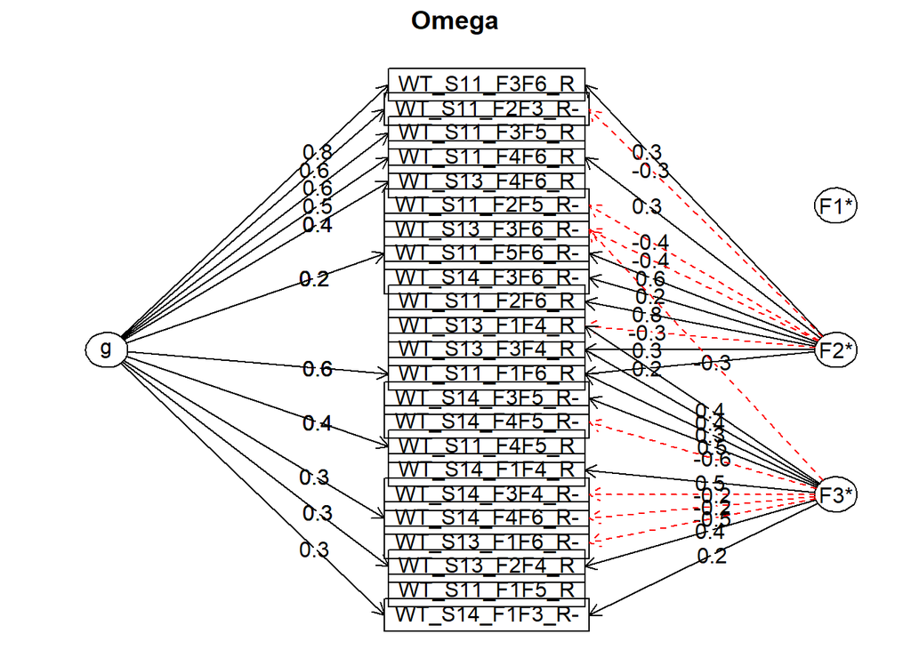

Omega Call: omegah(m = m, nfactors = nfactors, fm = fm, key = key, flip = flip, digits = digits, title = title, sl = sl, labels = labels, plot = plot, n.obs = n.obs, rotate = rotate, Phi = Phi, option = option, covar = covar) Alpha: 0.65 G.6: 0.84 Omega Hierarchical: 0.69 Omega H asymptotic: 0.94 Omega Total 0.74

Schmid Leiman Factor loadings greater than 0.2 g F1* F2* F3* h2 h2 u2 p2 com WT_S11_F1F5_R 0.06 0.94 0.51 2.02 WT_S11_F1F6_R 0.58 0.24 0.26 0.46 0.46 0.54 0.73 1.76 WT_S11_F2F3_R- 0.62 -0.29 0.49 0.49 0.51 0.78 1.57 WT_S11_F2F5_R- -0.38 0.16 0.84 0.11 1.26 WT_S11_F2F6_R 0.80 0.68 0.68 0.32 0.04 1.12 WT_S11_F3F5_R 0.60 0.37 0.37 0.63 0.96 1.09 WT_S11_F3F6_R 0.79 0.33 0.73 0.73 0.27 0.84 1.36 WT_S11_F4F5_R 0.41 0.22 0.22 0.78 0.76 1.64 WT_S11_F4F6_R 0.51 0.27 0.36 0.36 0.64 0.72 1.80 WT_S11_F5F6_R- 0.21 0.59 0.40 0.40 0.60 0.11 1.26 WT_S13_F1F4_R -0.33 0.41 0.29 0.29 0.71 0.02 1.99 WT_S13_F1F6_R- -0.50 0.29 0.29 0.71 0.11 1.28 WT_S13_F2F4_R 0.26 0.38 0.21 0.21 0.79 0.33 1.81 WT_S13_F3F4_R 0.25 0.37 0.21 0.21 0.79 0.07 2.01 WT_S13_F3F6_R- -0.38 -0.33 0.26 0.26 0.74 0.05 2.17 WT_S13_F4F6_R 0.40 0.19 0.81 0.85 1.35 WT_S14_F1F3_R- 0.34 0.24 0.18 0.82 0.67 1.81 WT_S14_F1F4_R 0.55 0.32 0.32 0.68 0.01 1.12 WT_S14_F3F4_R- -0.22 0.07 0.93 0.22 2.00 WT_S14_F3F5_R- 0.49 0.30 0.30 0.70 0.10 1.49 WT_S14_F3F6_R- 0.24 0.07 0.93 0.19 1.48 WT_S14_F4F5_R- -0.64 0.43 0.43 0.57 0.01 1.14 WT_S14_F4F6_R- 0.26 -0.23 0.12 0.88 0.54 2.13

With Sums of squares of: g F1* F2* F3* h2 2.80 0.01 1.97 2.11 2.75

general/max 1.02 max/min = 211.46 mean percent general = 0.38 with sd = 0.34 and cv of 0.89 Explained Common Variance of the general factor = 0.41

The degrees of freedom are 187 and the fit is 6.03 The number of observations was 72 with Chi Square = 365.08 with prob < 1.3e-13 The root mean square of the residuals is 0.1 The df corrected root mean square of the residuals is 0.12 RMSEA index = 0.114 and the 10 % confidence intervals are 0.098 0.133 BIC = -434.66

Compare this with the adequacy of just a general factor and no group factors The degrees of freedom for just the general factor are 230 and the fit is 8.49 The number of observations was 72 with Chi Square = 525.16 with prob < 4e-25 The root mean square of the residuals is 0.15 The df corrected root mean square of the residuals is 0.16

RMSEA index = 0.133 and the 10 % confidence intervals are 0.119 0.15 BIC = -458.47

Measures of factor score adequacy  
g F1* F2* F3* Correlation of scores with factors 0.93 0.06 0.9 0.87 Multiple R square of scores with factors 0.86 0.00 0.8 0.76 Minimum correlation of factor score estimates 0.72 -0.99 0.6 0.52

Total, General and Subset omega for each subset g F1* F2* F3* Omega total for total scores and subscales 0.74 NA 0.67 0.44 Omega general for total scores and subscales 0.69 NA 0.63 0.35 Omega group for total scores and subscales 0.05 NA 0.04 0.09